# Emotion Inertia Analysis

Rongrong (Emma) Mo

## Descriptive statistics

```r
feelings_initial <- load("feelings_initial.RData")
ls()
```

```
[1] "dat"              "feelings_initial" "Iaro_wide"        "Ineg_wide"        "Ipos_wide"
```

```r
summary(feelings_initial)
```

```
   Length     Class      Mode
        4 character character
```

```r
str(dat)
```

```
'data.frame':   16380 obs. of  9 variables:
 $ subj     : Factor w/ 156 levels "f001","f002",..: 1 1 1 1 1 1 1 1 1 1 ...
 $ trial.num: int  1 2 3 4 5 6 7 8 9 10 ...
 $ trial.val: Factor w/ 3 levels "neg","neu","pos": 3 1 1 3 3 2 2 1 1 3 ...
 $ sex      : Factor w/ 3 levels "male","female",..: 2 2 2 2 2 2 2 2 2 2 ...
 $ age      : int  19 19 19 19 19 19 19 19 19 19 ...
 $ ethn     : Factor w/ 7 levels "Asian or Pacific Islander",..: 1 1 1 1 1 1 1 1 1 1 ...
 $ Ineg     : num  1 4 2 1 1 1 1 3 5 1 ...
 $ Ipos     : num  3.69 1 1 1 4 ...
 $ Iaro     : num  2.86 3 2 2 3 ...
```

```r
library(dplyr)
participant_info <- dat %>% distinct(subj, age, sex, ethn)
participant_info
```

| subj | age | sex | ethn |
| --- | --- | --- | --- |
| f001 | 19 | female | Asian or Pacific Islander |
| f002 | 25 | female | Black/African American |
| f003 | 19 | female | Asian or Pacific Islander |
| f004 | 19 | female | Black/African American |
| f005 | 20 | female | Latino/Hispanic |
| f006 | 21 | female | White/Caucasian |
| f007 | 20 | female | Other |
| f008 | 23 | female | White/Caucasian |
| f009 | 19 | female | Asian or Pacific Islander |
| f010 | 24 | female | Latino/Hispanic |

[output cut: 146 more lines]

```r
mean_age <- mean(participant_info$age, na.rm = TRUE)
cat("Mean age:", mean_age, "\n")
```

```
Mean age: 20.82051
```

```r
sd_age <- sd(participant_info$age, na.rm = TRUE)
cat("SD of age:", sd_age, "\n")
```

```
SD of age: 2.936944
```

```r
female_prop <- mean(participant_info$sex == "female", na.rm = TRUE)
cat("Proportion of female participants:", female_prop)
```

```
Proportion of female participants: 0.5320513
```

```r
summary(dat[, c("Ineg", "Ipos", "Iaro")])
```

```
      Ineg            Ipos            Iaro
 Min.   :1.000   Min.   :1.000   Min.   :1.000
 1st Qu.:1.000   1st Qu.:1.000   1st Qu.:1.000
 Median :2.000   Median :2.000   Median :3.000
 Mean   :3.075   Mean   :3.066   Mean   :3.265
 3rd Qu.:5.000   3rd Qu.:5.000   3rd Qu.:5.000
 Max.   :9.000   Max.   :9.000   Max.   :9.000
```

- Mean score of Iaro is higher than the other two

```r
# identify NAs
colSums(is.na(dat))
```

```
     subj trial.num trial.val       sex       age      ethn      Ineg      Ipos      Iaro
        0         0         0         0         0         0         0         0         0
```

There are no NAs in the dataset.

```r
# identify outliers using z-score

# Calculate Z-scores for Ineg, Ipos, and Iaro
dat$z_Ineg <- scale(dat$Ineg)
dat$z_Ipos <- scale(dat$Ipos)
dat$z_Iaro <- scale(dat$Iaro)

# Identify outliers (Z-score > 3 or < -3)
outliers_Ineg <- dat[abs(dat$z_Ineg) > 3, ]
outliers_Ineg
```

| subj | trial.num | trial.val | sex | age | ethn | Ineg | Ipos | Iaro | z_Ineg | z_Ipos | z_Iaro |
| --- | --- | --- | --- | --- | --- | --- | --- | --- | --- | --- | --- |

```r
outliers_Ipos <- dat[abs(dat$z_Ipos) > 3, ]
outliers_Ipos
```

| subj | trial.num | trial.val | sex | age | ethn | Ineg | Ipos | Iaro | z_Ineg | z_Ipos | z_Iaro |
| --- | --- | --- | --- | --- | --- | --- | --- | --- | --- | --- | --- |

```r
outliers_Iaro <- dat[abs(dat$z_Iaro) > 3, ]
outliers_Iaro
```

| subj | trial.num | trial.val | sex | age | ethn | Ineg | Ipos | Iaro | z_Ineg | z_Ipos | z_Iaro |
| --- | --- | --- | --- | --- | --- | --- | --- | --- | --- | --- | --- |

```r
NA
```

There are no outliers.

## Linear Mixed Effects Model: emotional responses by trial type & demographics

- Each participant has multiple trials, so the trials within a participant are likely correlated
- Data is nested
- Each participant may have their own baseline level of emotional responses
- fixed effects (trial.val, sex, age, ethn) explain the variation between individuals
- random effects (1|subj) explain the correlation of repeated measures within individuals

### How different trial types & demographics affect negative emotional response (Ineg)?

```r
library(lme4)
# Mixed-effects model for predicting Ineg
model_ineg <- lmer(Ineg ~ trial.val + sex + age + ethn + (1|subj), data = dat)
summary(model_ineg)
```

```
Linear mixed model fit by REML ['lmerMod']
Formula: Ineg ~ trial.val + sex + age + ethn + (1 | subj)
   Data: dat

REML criterion at convergence: 58969.5

Scaled residuals:
    Min      1Q  Median      3Q     Max
-3.9915 -0.5714 -0.0487  0.5031  5.6660

Random effects:
 Groups   Name        Variance Std.Dev.
 subj     (Intercept) 0.5259   0.7252
 Residual             2.0745   1.4403
Number of obs: 16380, groups:  subj, 156

Fixed effects:
                                                       Estimate Std. Error  t value
(Intercept)                                            5.218934   0.443816   11.759
trial.valneu                                          -4.076439   0.034381 -118.566
trial.valpos                                          -4.086175   0.024311 -168.079
sexfemale                                              0.317543   0.121858    2.606
sexother                                              -0.031652   0.747300   -0.042
age                                                    0.001809   0.021086    0.086
ethnBlack/African American                            -0.060943   0.237892   -0.256
ethnLatino/Hispanic                                   -0.317652   0.232008   -1.369
ethnOther                                              0.138570   0.290750    0.477
ethnWhite/Caucasian                                    0.070420   0.155354    0.453
ethnAmerican Indian/Native American or Alaskan Native -0.692261   0.393608   -1.759
ethnDecline to state                                  -0.275510   0.543413   -0.507

Correlation of Fixed Effects:
            (Intr) trl.vln trl.vlp sexfml sexthr age    etB/AA ethL/H ethnOt ethW/C eIAoAN
trial.valne -0.019
trial.valps -0.027  0.354
sexfemale   -0.197  0.000   0.000
sexother    -0.070  0.000   0.000   0.084
age         -0.941  0.000   0.000   0.021  0.059
ethnBlck/AA -0.026  0.000   0.000   0.072 -0.002 -0.149
ethnLtn/Hsp  0.065  0.000   0.000   0.072 -0.008 -0.250  0.334
ethnOther   -0.081  0.000   0.000  -0.044 -0.006 -0.038  0.234  0.244
ethnWht/Ccs -0.091  0.000   0.000   0.107 -0.062 -0.171  0.468  0.496  0.357
ethAI/NAoAN -0.141  0.000   0.000   0.123  0.012  0.029  0.176  0.178  0.134  0.271
ethnDclntst -0.067  0.000   0.000   0.144  0.010 -0.027  0.139  0.145  0.096  0.211  0.092
```

- Random effects: each participant has a different baseline emotional response
  - `(1|subj)`: represents the random effect
    - each participant (subj) has a different baseline deviation (intercept).
    - This accounts for the correlation between multiple trial results from the same participant
- `REML score` (residual maximum likelihood estimate): assess the model fit
- Fixed Effects:
  - Intercept: Negative trial
  - `trial.valneu` (Neutral trial): Estimate = -4.08, t = -118.57, a very significant negative value.
    - Compared to the baseline (negative trial), **the neutral trial significantly decreases negative emotions (Ineg)**
  - `trial.valpos` (Positive trial): Estimate = -4.09, t = -168.08, also significant.
    - **the positive trial also significantly decreases negative emotions** compared to the negative trial
  - sexfemale: Estimate = 0.317543, t = 2.606.
    - **Females have significantly higher negative emotional responses (Ineg)** compared to males
  - The effects of age and ethnicity are small and not significant

### How different trial types & demographics affect positive emotional response (Ipos)?

```r
# Mixed-effects model for predicting Ipos
model_ipos <- lmer(Ipos ~ trial.val + sex + age + ethn + (1|subj), data = dat)
summary(model_ipos)
```

```
Linear mixed model fit by REML ['lmerMod']
Formula: Ipos ~ trial.val + sex + age + ethn + (1 | subj)
   Data: dat

REML criterion at convergence: 60034.7

Scaled residuals:
    Min      1Q  Median      3Q     Max
-3.8302 -0.5834 -0.0294  0.5335  5.4659

Random effects:
 Groups   Name        Variance Std.Dev.
 subj     (Intercept) 0.5687   0.7541
 Residual             2.2138   1.4879
Number of obs: 16380, groups:  subj, 156

Fixed effects:
                                                      Estimate Std. Error t value
(Intercept)                                            0.71768    0.46141   1.555
trial.valneu                                           0.33658    0.03552   9.477
trial.valpos                                           4.03432    0.02511 160.642
sexfemale                                              0.20020    0.12669   1.580
sexother                                              -1.13135    0.77693  -1.456
age                                                    0.02213    0.02192   1.010
ethnBlack/African American                             0.08731    0.24732   0.353
ethnLatino/Hispanic                                   -0.33718    0.24121  -1.398
ethnOther                                             -0.01740    0.30228  -0.058
ethnWhite/Caucasian                                    0.13375    0.16151   0.828
ethnAmerican Indian/Native American or Alaskan Native -0.93997    0.40921  -2.297
ethnDecline to state                                  -0.33289    0.56496  -0.589

Correlation of Fixed Effects:
            (Intr) trl.vln trl.vlp sexfml sexthr age    etB/AA ethL/H ethnOt ethW/C eIAoAN
trial.valne -0.019
trial.valps -0.027  0.354
sexfemale   -0.197  0.000   0.000
sexother    -0.070  0.000   0.000   0.084
age         -0.941  0.000   0.000   0.021  0.059
ethnBlck/AA -0.026  0.000   0.000   0.072 -0.002 -0.149
ethnLtn/Hsp  0.065  0.000   0.000   0.072 -0.008 -0.250  0.334
ethnOther   -0.081  0.000   0.000  -0.044 -0.006 -0.038  0.234  0.244
ethnWht/Ccs -0.091  0.000   0.000   0.107 -0.062 -0.171  0.468  0.496  0.357
ethAI/NAoAN -0.141  0.000   0.000   0.123  0.012  0.029  0.176  0.178  0.134  0.271
ethnDclntst -0.067  0.000   0.000   0.144  0.010 -0.027  0.139  0.145  0.096  0.211  0.092
```

- Intercept (negative trial): estimate = 0.72, t-value = 1.56. The effect of negative trial on positive emotions (Ipos) is small.
- `trial.valneu`: estimate = 0.34, t-value = 9.48. Compared to valneg, the neutral trial significantly increases positive emotions (Ipos).
- `trial.valpos`: estimate = 4.03, t-value = 160.64. Compared to valneg, the positive trial largely increases positive emotions (Ipos), and the effect is extremely significant.
- `sexfemale`: estimate = 0.20, t = 1.58. **Females tend to have slightly higher positive emotional responses** than males.
- `ethnAmerican Indian/Native American or Alaskan Native`: estimate = -0.94, t = -2.30. This ethnicity tends to have **significantly lower positive emotional responses** compared to the reference group (Asian or Pacific Islander).
- `trial.valneu` and `trial.valpos` have a correlation of 0.354, showing that the effects of neutral and positive trials are somewhat related.

### How different trial types & demographics affect arousal emotional response (Iaro)?

```r
# Mixed-effects model for predicting Iaro
model_aro <- lmer(Iaro ~ trial.val + sex + age + ethn + (1|subj), data = dat)
summary(model_aro)
```

```
Linear mixed model fit by REML ['lmerMod']
Formula: Iaro ~ trial.val + sex + age + ethn + (1 | subj)
   Data: dat

REML criterion at convergence: 59841.3

Scaled residuals:
    Min      1Q  Median      3Q     Max
-4.4843 -0.6288 -0.1072  0.5760  4.8022

Random effects:
 Groups   Name        Variance Std.Dev.
 subj     (Intercept) 1.593    1.262
 Residual             2.168    1.472
Number of obs: 16380, groups:  subj, 156

Fixed effects:
                                                      Estimate Std. Error t value
(Intercept)                                            2.92802    0.76311   3.837
trial.valneu                                          -2.25913    0.03515 -64.279
trial.valpos                                          -0.30058    0.02485 -12.095
sexfemale                                              0.22642    0.20959   1.080
sexother                                              -1.53358    1.28529  -1.193
age                                                    0.02904    0.03627   0.801
ethnBlack/African American                             0.22313    0.40915   0.545
ethnLatino/Hispanic                                    0.12385    0.39903   0.310
ethnOther                                              0.52839    0.50007   1.057
ethnWhite/Caucasian                                    0.06932    0.26720   0.259
ethnAmerican Indian/Native American or Alaskan Native -0.85245    0.67697  -1.259
ethnDecline to state                                   0.07313    0.93462   0.078

Correlation of Fixed Effects:
            (Intr) trl.vln trl.vlp sexfml sexthr age    etB/AA ethL/H ethnOt ethW/C eIAoAN
trial.valne -0.012
trial.valps -0.016  0.354
sexfemale   -0.197  0.000   0.000
sexother    -0.070  0.000   0.000   0.084
age         -0.942  0.000   0.000   0.021  0.059
ethnBlck/AA -0.026  0.000   0.000   0.072 -0.002 -0.149
ethnLtn/Hsp  0.065  0.000   0.000   0.072 -0.008 -0.250  0.334
ethnOther   -0.081  0.000   0.000  -0.044 -0.006 -0.038  0.234  0.244
ethnWht/Ccs -0.091  0.000   0.000   0.107 -0.062 -0.171  0.468  0.496  0.357
ethAI/NAoAN -0.141  0.000   0.000   0.123  0.012  0.029  0.176  0.178  0.134  0.271
ethnDclntst -0.067  0.000   0.000   0.144  0.010 -0.027  0.139  0.145  0.096  0.211  0.092
```

- Intercept (negative trial): estimate = 2.93, t-value = 3.84. The effect of negative trial on arousal (Iaro) is moderate.
- `trial.valneu`: estimate -2.26, t-value = -64.28. Compared to `valneg`, the **neutral trial significantly decreases arousal (Iaro)**, which can be expected.
- `trial.valpos`: estimate = -0.30, t-value = -12.10. Compared to `valneg`, the **positive trial also significantly decreases arousal (Iaro)**, but the effect is small.
- Other fixed effects are not significant.

## Autoregressive Modeling

### Assign 12 inertia scores for each participant

Assign 1 overall inertia score for pos, neg, and aro for each participant:

```r
library(dplyr)
library(purrr)
library(broom)

# Create a function to return inertia (lag-1 beta value)
get_inertia <- function(x) {
  # Create lagged data
  lag_x <- dplyr::lag(x)
  df <- data.frame(current = x, lagged = lag_x)
  df <- na.omit(df)

  # Linear regression: current ~ lagged
  model <- lm(current ~ lagged, data = df)
  coef(model)["lagged"]
}

# find inertia scores for the 3 emotions for each participant
overall_inertia <- dat %>%
  group_by(subj) %>%
  summarise(
    pos_inertia = get_inertia(Ipos),
    neg_inertia = get_inertia(Ineg),
    aro_inertia = get_inertia(Iaro)
  )
overall_inertia
```

| subj | pos_inertia | neg_inertia | aro_inertia |
| --- | --- | --- | --- |
| f001 | -0.095640979 | -0.1488451295 | -1.388733e-01 |
| f002 | 0.018675315 | 0.0682464455 | 9.739926e-02 |
| f003 | -0.085549181 | -0.1431158134 | 1.486716e-02 |
| f004 | 0.064783738 | -0.0704655902 | 1.496546e-02 |
| f005 | -0.043348586 | -0.0917502276 | -9.618421e-02 |
| f006 | -0.075028182 | 0.1603263155 | 1.750280e-01 |
| f007 | 0.083363926 | 0.0244823314 | 1.902843e-01 |
| f008 | -0.012542355 | -0.0254163319 | 9.490323e-03 |
| f009 | 0.016219574 | 0.0865441786 | -1.357805e-01 |
| f010 | 0.164331935 | 0.1095890411 | 1.433121e-02 |

[output cut: 146 more lines]

For each of the 3 emotional reactions (pos, neg, aro), assign 1 inertia score for each of the 3 trial type (pos, neg, neu)

```r
library(tidyr)
# For each subj × trial.val × emotion
inertia_long <- dat %>%
  group_by(subj, trial.val) %>%
  summarise(
    pos_inertia = get_inertia(Ipos),
    neg_inertia = get_inertia(Ineg),
    aro_inertia = get_inertia(Iaro),
    .groups = "drop"
  )

# Reshape into wide format: 1 row per participant, 9 inertia scores
inertia_wide <- inertia_long %>%
  pivot_wider(
    names_from = trial.val,
    values_from = c(pos_inertia, neg_inertia, aro_inertia),
    names_glue = "{.value}_{trial.val}"
  )

inertia_wide
```

| subj | pos_inertia_neg | pos_inertia_neu | pos_inertia_pos | neg_inertia_neg | neg_inertia_neu | neg_inertia_pos | aro_inertia_neg | aro_inertia_neu | aro_inertia_pos |
| --- | --- | --- | --- | --- | --- | --- | --- | --- | --- |
| f001 | -2.325581e-02 | NA | 0.0213952398 | -0.202973497 | NA | NA | -0.1870503597 | 2.500000e-01 | 0.038539731 |
| f002 | -2.325581e-02 | -0.115384615 | -0.0041841004 | 0.376453488 | NA | NA | 0.0697151424 | 7.575758e-03 | -0.202898551 |
| f003 | 1.311350e-01 | -0.093922652 | -0.1271732131 | -0.105724382 | -0.223684211 | -3.631011e-02 | 0.0607018653 | -3.360996e-01 | -0.256530002 |
| f004 | -7.317073e-02 | -0.011111111 | 0.1958333333 | 0.068882899 | 0.176470588 | -1.282051e-01 | -0.0063291139 | 3.768116e-01 | 0.224525043 |
| f005 | 2.226148e-01 | -0.076923077 | 0.0571031186 | 0.106911572 | NA | 3.366584e-02 | 0.1261960643 | -7.692308e-02 | -0.183265719 |
| f006 | -8.833922e-02 | -0.161290323 | 0.2394819487 | 0.415973378 | -0.076923077 | -4.761905e-02 | 0.4679064187 | -7.692308e-02 | 0.090476190 |
| f007 | -2.325581e-02 | -0.088827477 | 0.0635574459 | 0.191246432 | NA | NA | 0.1154518950 | NA | -0.163043478 |
| f008 | 4.219205e-02 | -0.247422680 | 0.0362744731 | -0.173609241 | -0.076923077 | 2.511141e-01 | -0.2209576268 | -1.818182e-01 | -0.158877884 |
| f009 | -5.601715e-02 | 0.058951965 | 0.0651938206 | 0.060272934 | -0.431226766 | -6.081324e-02 | -0.1054135531 | 1.752577e-01 | -0.269397802 |
| f010 | -2.325581e-02 | 0.057692308 | 0.1991199120 | 0.220085470 | -0.076923077 | 4.110899e-01 | 0.0434782609 | 0.000000e+00 | 0.146341463 |

[output cut: 146 more lines]

```r
# Find the reason of NAs

# Whether there's not enough data for each subj × trial.val group?

dat %>%
  group_by(subj, trial.val) %>%
  summarise(n = n()) %>%
  filter(n < 5)
```

| subj | trial.val | n |
| --- | --- | --- |

```r
# Whether some emotion ratings for certain trial type are always the same?

dat %>%
  group_by(subj, trial.val) %>%
  summarise(
    Ineg_var = var(Ineg),
    Ipos_var = var(Ipos),
    Iaro_var = var(Iaro)
  ) %>%
  filter(Ineg_var == 0 | Ipos_var == 0 | Iaro_var == 0)
```

| subj | trial.val | Ineg_var | Ipos_var | Iaro_var |
| --- | --- | --- | --- | --- |
| f001 | neu | 0.00000000 | 0.26666667 | 0.35238095 |
| f001 | pos | 0.00000000 | 1.61174130 | 1.08486910 |
| f002 | neu | 0.00000000 | 1.25714286 | 1.35238095 |
| f002 | pos | 0.00000000 | 1.51010101 | 1.14343434 |
| f005 | neu | 0.00000000 | 0.26666667 | 0.06666667 |
| f007 | neu | 0.00000000 | 0.06632653 | 0.00000000 |
| f007 | pos | 0.00000000 | 0.78647702 | 0.38181818 |
| f013 | neu | 0.00000000 | 0.06593407 | 0.00000000 |
| f019 | neu | 0.12380952 | 4.92380952 | 0.00000000 |
| f020 | neu | 0.00000000 | 2.52380952 | 1.55238095 |

[output cut: 96 more lines]

- The reason of NAs is not due to insufficient data for each subj × trial.val group
- NAs are also not likely to be caused by zero-variance of some emotion inertia ratings, since NAs from inertia_wide are more than the number of Var = 0.

```r
# Merge all inertia scores (by subj)
inertia_all <- overall_inertia %>%
  left_join(inertia_wide, by = "subj")
inertia_all
```

| subj | pos_inertia | neg_inertia | aro_inertia | pos_inertia_neg | pos_inertia_neu | pos_inertia_pos | neg_inertia_neg | neg_inertia_neu | neg_inertia_pos | aro_inertia_neg | aro_inertia_neu | aro_inertia_pos |
| --- | --- | --- | --- | --- | --- | --- | --- | --- | --- | --- | --- | --- |
| f001 | -0.095640979 | -0.1488451295 | -1.388733e-01 | -2.325581e-02 | NA | 0.0213952398 | -0.202973497 | NA | NA | -0.1870503597 | 2.500000e-01 | 0.038539731 |
| f002 | 0.018675315 | 0.0682464455 | 9.739926e-02 | -2.325581e-02 | -0.115384615 | -0.0041841004 | 0.376453488 | NA | NA | 0.0697151424 | 7.575758e-03 | -0.202898551 |
| f003 | -0.085549181 | -0.1431158134 | 1.486716e-02 | 1.311350e-01 | -0.093922652 | -0.1271732131 | -0.105724382 | -0.223684211 | -3.631011e-02 | 0.0607018653 | -3.360996e-01 | -0.256530002 |
| f004 | 0.064783738 | -0.0704655902 | 1.496546e-02 | -7.317073e-02 | -0.011111111 | 0.1958333333 | 0.068882899 | 0.176470588 | -1.282051e-01 | -0.0063291139 | 3.768116e-01 | 0.224525043 |
| f005 | -0.043348586 | -0.0917502276 | -9.618421e-02 | 2.226148e-01 | -0.076923077 | 0.0571031186 | 0.106911572 | NA | 3.366584e-02 | 0.1261960643 | -7.692308e-02 | -0.183265719 |
| f006 | -0.075028182 | 0.1603263155 | 1.750280e-01 | -8.833922e-02 | -0.161290323 | 0.2394819487 | 0.415973378 | -0.076923077 | -4.761905e-02 | 0.4679064187 | -7.692308e-02 | 0.090476190 |
| f007 | 0.083363926 | 0.0244823314 | 1.902843e-01 | -2.325581e-02 | -0.088827477 | 0.0635574459 | 0.191246432 | NA | NA | 0.1154518950 | NA | -0.163043478 |
| f008 | -0.012542355 | -0.0254163319 | 9.490323e-03 | 4.219205e-02 | -0.247422680 | 0.0362744731 | -0.173609241 | -0.076923077 | 2.511141e-01 | -0.2209576268 | -1.818182e-01 | -0.158877884 |
| f009 | 0.016219574 | 0.0865441786 | -1.357805e-01 | -5.601715e-02 | 0.058951965 | 0.0651938206 | 0.060272934 | -0.431226766 | -6.081324e-02 | -0.1054135531 | 1.752577e-01 | -0.269397802 |
| f010 | 0.164331935 | 0.1095890411 | 1.433121e-02 | -2.325581e-02 | 0.057692308 | 0.1991199120 | 0.220085470 | -0.076923077 | 4.110899e-01 | 0.0434782609 | 0.000000e+00 | 0.146341463 |

[output cut: 146 more lines]

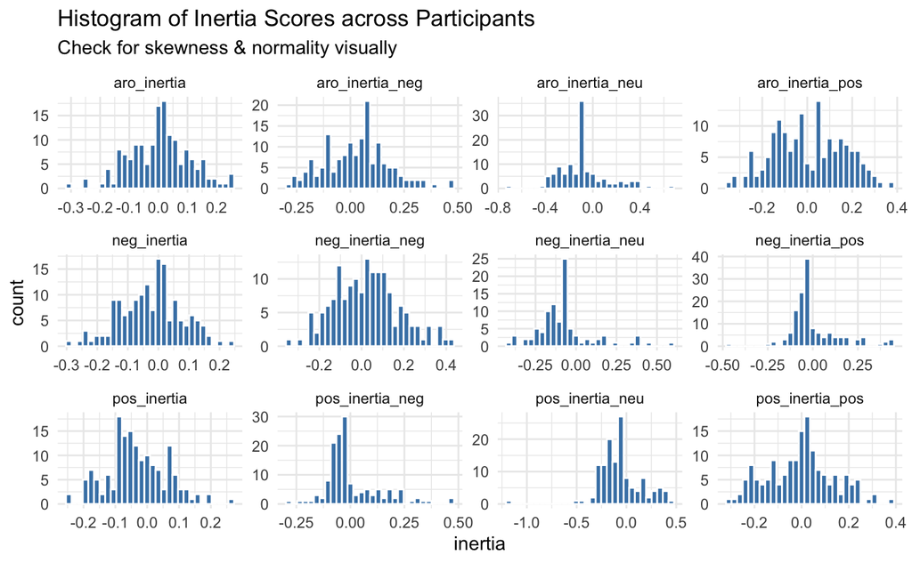

```r
library(ggplot2)
library(dplyr)
library(tidyr)
library(e1071)   # for skewness
library(psych)   # for describe()
# Convert to inertia_long format
inertia_long <- inertia_all %>%
  pivot_longer(-subj, names_to = "inertia_type", values_to = "inertia")

# Distribution & Skewness
inertia_long %>%
  group_by(inertia_type) %>%
  mutate(
    skew = skewness(inertia, na.rm = TRUE),
    normality_p = shapiro.test(inertia)$p.value
  ) %>%
  ggplot(aes(x = inertia)) +
  geom_histogram(bins = 30, fill = "steelblue", color = "white") +
  facet_wrap(~ inertia_type, scales = "free") +
  theme_minimal() +
  labs(title = "Histogram of Inertia Scores across Participants",
       subtitle = "Check for skewness & normality visually")
```

```r
# describe_stats for all 3 + 9 = 12 types of inertia
describe_stats <- inertia_long %>%
  group_by(inertia_type) %>%
  summarise(
    n = sum(!is.na(inertia)),
    sd = sd(inertia, na.rm = TRUE),
    Q1 = quantile(inertia, 0.25, na.rm = TRUE),
    Q3 = quantile(inertia, 0.75, na.rm = TRUE),
    skewness = skewness(inertia, na.rm = TRUE),
    normality_p = shapiro.test(inertia)$p.value
  )
describe_stats
```

| inertia_type | n | sd | Q1 | Q3 | skewness | normality_p |
| --- | --- | --- | --- | --- | --- | --- |
| aro_inertia | 156 | 0.10290647 | -0.06297185 | 0.066614526 | -0.08094839 | 6.097208e-01 |
| aro_inertia_neg | 156 | 0.14987174 | -0.07718291 | 0.123964873 | 0.22960089 | 1.385261e-01 |
| aro_inertia_neu | 117 | 0.20763094 | -0.18181818 | -0.009473684 | 0.71497318 | 3.859573e-05 |
| aro_inertia_pos | 154 | 0.15746349 | -0.11731839 | 0.134195215 | 0.03675840 | 1.105345e-01 |
| neg_inertia | 156 | 0.09983429 | -0.08900254 | 0.031589982 | -0.12022526 | 8.166439e-01 |
| neg_inertia_neg | 156 | 0.15131866 | -0.09283016 | 0.117105763 | 0.25324613 | 4.156617e-01 |
| neg_inertia_neu | 95 | 0.17686943 | -0.16583768 | -0.063461538 | 1.29575508 | 1.296106e-07 |
| neg_inertia_pos | 141 | 0.13921266 | -0.06942004 | 0.045783133 | 1.07982750 | 6.689087e-10 |
| pos_inertia | 156 | 0.09271517 | -0.08891990 | 0.027552744 | 0.28969376 | 2.665822e-01 |
| pos_inertia_neg | 140 | 0.12888373 | -0.06912918 | 0.047913377 | 1.27067898 | 2.318693e-09 |

[output cut: 2 more lines]

Inertia scores that are not normal:

- neg_inertia_pos: normality_p = 6.689087e-10; skewness = 1.07982750
  - Under positive stimuli, negative emotion inertia is right-skewed: a few individuals have unusually persistent negative emotions
- pos_inertia_neg: normality_p = 2.318693e-09; skewness = 1.27067898
  - Under negative stimuli, positive emotion inertia is strongly right-skewed: most people have low inertia in positive feelings, with a few showing strong inertia
- pos_inertia_neu: normality_p = 8.436415e-08; skewness = -0.39896752
  - For neutral stimuli, positive emotion inertia is slightly left-skewed
- neg_inertia_neu: normality_p = 1.296106e-07; skewness = 1.29575508
  - For neutral stimuli, negative emotion inertia is strongly right-skewed
- aro_inertia_neu: normality_p = 3.859573e-05; skewness = 0.71497318
  - For neutral stimuli, arousal inertia is right-skewed

### Normalize the skewed inertia types

```r
# Transform the skewed inertia types to normal
library(bestNormalize)
skewed_vars <- c(
  "neg_inertia_pos", "pos_inertia_neg", "pos_inertia_neu",
  "neg_inertia_neu", "aro_inertia_neu"
)

inertia_long_normalized <- inertia_long %>%
  group_by(inertia_type) %>%
  mutate(
    inertia_trans = if_else(
      inertia_type %in% skewed_vars,
      orderNorm(inertia)$x.t,  # transform only these
      inertia  # leave others unchanged
    )
  )
inertia_long_normalized
```

| subj | inertia_type | inertia | inertia_trans |
| --- | --- | --- | --- |
| f001 | pos_inertia | -9.564098e-02 | -0.0956409794 |
| f001 | neg_inertia | -1.488451e-01 | -0.1488451295 |
| f001 | aro_inertia | -1.388733e-01 | -0.1388732950 |
| f001 | pos_inertia_neg | -2.325581e-02 | 0.2441135777 |
| f001 | pos_inertia_neu | NA | NA |
| f001 | pos_inertia_pos | 2.139524e-02 | 0.0213952398 |
| f001 | neg_inertia_neg | -2.029735e-01 | -0.2029734971 |
| f001 | neg_inertia_neu | NA | NA |
| f001 | neg_inertia_pos | NA | NA |
| f001 | aro_inertia_neg | -1.870504e-01 | -0.1870503597 |

[output cut: 990 more lines]

### Compare means and sd of the 12 inertia types

```r
# Find mean value of each of the 12 inertia types

inertia_means <- inertia_long_normalized %>%
  group_by(inertia_type) %>%
  summarise(
    mean_inertia = mean(inertia_trans, na.rm = TRUE),
    sd_inertia = sd(inertia_trans, na.rm = TRUE),
    n = sum(!is.na(inertia_trans))
  ) %>%
  arrange(desc(abs(mean_inertia)))

inertia_means
```

| inertia_type | mean_inertia | sd_inertia | n |
| --- | --- | --- | --- |
| pos_inertia | -3.241797e-02 | 0.09271517 | 156 |
| aro_inertia_neg | 3.080457e-02 | 0.14987174 | 156 |
| neg_inertia | -2.436017e-02 | 0.09983429 | 156 |
| neg_inertia_neg | 2.423859e-02 | 0.15131866 | 156 |
| aro_inertia_pos | 6.932816e-03 | 0.15746349 | 154 |
| pos_inertia_pos | -5.892885e-03 | 0.14069092 | 156 |
| aro_inertia | 4.824740e-03 | 0.10290647 | 156 |
| neg_inertia_neu | -5.232923e-05 | 0.99825675 | 95 |
| aro_inertia_neu | -4.404061e-05 | 0.99839880 | 117 |
| pos_inertia_neg | -3.275277e-05 | 0.99886705 | 140 |

[output cut: 2 more lines]

- aro_inertia_neu: Extremely high SD (0.998) — arousal inertia under neutral stimuli varies greatly across individuals
- neg_inertia_pos: Negative near-zero mean (-9.32e-06) but very high variance (sd = 0.999);
  - Negative emotion is likely to bounce back after positive stimuli
  - Huge individual differences
- pos_inertia_neg: Negative near-zero mean (-3.28e-05) but very high variance (sd = 0.999);
  - Positive emotion is likely to bounce back after negative stimuli
  - Huge individual differences

#### aro_inertia_neg (mean = 0.031) vs. aro_inertia_pos (mean = 0.007)

- participants show slightly greater arousal persistence following negative stimuli (M = 0.0308) compared to positive stimuli
- but the difference is non-significant (p-value = 0.1727)

```r
library(dplyr)
library(broom)
library(effectsize)
inertia_compare_aro <- inertia_long_normalized %>%
  filter(inertia_type %in% c("aro_inertia_neg", "aro_inertia_pos")) %>%
  filter(!is.na(inertia_trans))

t_result_aro <- t.test(inertia_trans ~ inertia_type, data = inertia_compare_aro)
print(t_result_aro)
```

```
    Welch Two Sample t-test

data:  inertia_trans by inertia_type
t = 1.3669, df = 306.81, p-value = 0.1727
alternative hypothesis: true difference in means between group aro_inertia_neg and group aro_inertia_pos is not equal to 0
95 percent confidence interval:
 -0.01049249  0.05823600
sample estimates:
mean in group aro_inertia_neg mean in group aro_inertia_pos
                  0.030804571                   0.006932816
```

```r
cohen_d_result_aro <- cohens_d(inertia_trans ~ inertia_type, data = inertia_compare_aro)
print(cohen_d_result_aro)
```

```
Cohen's d |        95% CI
-------------------------
0.16      | [-0.07, 0.38]

- Estimated using pooled SD.
```

```r
anova_result_aro <- aov(inertia_trans ~ inertia_type, data = inertia_compare_aro)
summary(anova_result_aro)
```

```
              Df Sum Sq Mean Sq F value Pr(>F)
inertia_type   1  0.044 0.04416    1.87  0.173
Residuals    308  7.275 0.02362
```

```r
eta_squared_result_aro <- eta_squared(anova_result_aro, partial = TRUE)
```

```
For one-way between subjects designs, partial eta squared is equivalent to eta squared.
  Returning eta squared.
```

```r
print(eta_squared_result_aro)
```

```
# Effect Size for ANOVA

Parameter    |     Eta2 |       95% CI
--------------------------------------
inertia_type | 6.03e-03 | [0.00, 1.00]

- One-sided CIs: upper bound fixed at [1.00].
```

#### neg_inertia (mean = -0.024) vs. pos_inertia (mean = -0.032):

```r
inertia_compare_negpos <- inertia_long_normalized %>%
  filter(inertia_type %in% c("neg_inertia", "pos_inertia")) %>%
  filter(!is.na(inertia_trans))

t_result_negpos <- t.test(inertia_trans ~ inertia_type, data = inertia_compare_negpos)
print(t_result_negpos)
```

```
    Welch Two Sample t-test

data:  inertia_trans by inertia_type
t = 0.73868, df = 308.32, p-value = 0.4607
alternative hypothesis: true difference in means between group neg_inertia and group pos_inertia is not equal to 0
95 percent confidence interval:
 -0.01340656  0.02952216
sample estimates:
mean in group neg_inertia mean in group pos_inertia
              -0.02436017               -0.03241797
```

```r
cohen_d_result_negpos <- cohens_d(inertia_trans ~ inertia_type, data = inertia_compare_negpos)
print(cohen_d_result_negpos)
```

```
Cohen's d |        95% CI
-------------------------
0.08      | [-0.14, 0.31]

- Estimated using pooled SD.
```

```r
anova_result_negpos <- aov(inertia_trans ~ inertia_type, data = inertia_compare_negpos)
summary(anova_result_negpos)
```

```
              Df Sum Sq  Mean Sq F value Pr(>F)
inertia_type   1 0.0051 0.005064   0.546  0.461
Residuals    310 2.8773 0.009281
```

```r
eta_squared_result_negpos <- eta_squared(anova_result_negpos, partial = TRUE)
```

```
For one-way between subjects designs, partial eta squared is equivalent to eta squared.
  Returning eta squared.
```

```r
print(eta_squared_result_negpos)
```

```
# Effect Size for ANOVA

Parameter    |     Eta2 |       95% CI
--------------------------------------
inertia_type | 1.76e-03 | [0.00, 1.00]

- One-sided CIs: upper bound fixed at [1.00].
```

- **Negative emotions appeared to decay slightly more slowly (M = –0.024) than positive ones (M = –0.032), but the difference is not significant (p-value = 0.461)**
- on average, both emotional valences exhibited similarly rapid decay, and individual variability may overshadow any consistent group-level differences
- Cohen’s d effect size = 0.08: difference between `neg_inertia` and `pos_inertia` is small

#### neg_inertia_pos (mean = -9.32e-06) vs. pos_inertia_neg (-3.28e-05):

```r
inertia_compare_negpos2 <- inertia_long_normalized %>%
  filter(inertia_type %in% c("neg_inertia_pos", "pos_inertia_neg")) %>%
  filter(!is.na(inertia_trans))

t_result_negpos2 <- t.test(inertia_trans ~ inertia_type, data = inertia_compare_negpos2)
print(t_result_negpos2)
```

```
    Welch Two Sample t-test

data:  inertia_trans by inertia_type
t = 0.00019662, df = 278.99, p-value = 0.9998
alternative hypothesis: true difference in means between group neg_inertia_pos and group pos_inertia_neg is not equal to 0
95 percent confidence interval:
 -0.2345872  0.2346341
sample estimates:
mean in group neg_inertia_pos mean in group pos_inertia_neg
                -9.318999e-06                 -3.275277e-05
```

```r
cohen_d_result_negpos2 <- cohens_d(inertia_trans ~ inertia_type, data = inertia_compare_negpos2)
print(cohen_d_result_negpos2)
```

```
Cohen's d |        95% CI
-------------------------
2.35e-05  | [-0.23, 0.23]

- Estimated using pooled SD.
```

```r
anova_result_negpos2 <- aov(inertia_trans ~ inertia_type, data = inertia_compare_negpos2)
summary(anova_result_negpos2)
```

```
              Df Sum Sq Mean Sq F value Pr(>F)
inertia_type   1    0.0  0.0000       0      1
Residuals    279  278.4  0.9978
```

```r
eta_squared_result_negpos2 <- eta_squared(anova_result_negpos2, partial = TRUE)
```

```
For one-way between subjects designs, partial eta squared is equivalent to eta squared.
  Returning eta squared.
```

```r
print(eta_squared_result_negpos2)
```

```
# Effect Size for ANOVA

Parameter    |     Eta2 |       95% CI
--------------------------------------
inertia_type | 1.39e-10 | [0.00, 1.00]

- One-sided CIs: upper bound fixed at [1.00].
```

- Interpretation: **Emotions tend to reset quickly when the stimulus is the opposite, potentially due to contrast effects or attentional shifts, meaning that people are likely to be affected by opposite stimuli**
- **no statistically significant difference (p = 0.9998)**
- Cohen’s d effect size = 2.35e-05: difference between `neg_inertia_pos` and `pos_inertia_neg` is negligible

#### pos_inertia_pos vs. pos_inertia_neg:

```r
# pos_inertia_pos vs. pos_inertia_neg: effect size

pos_pos_vs_pos_neg <- inertia_long_normalized %>%
  filter(inertia_type %in% c("pos_inertia_pos", "pos_inertia_neg")) %>%
  filter(!is.na(inertia_trans))

t_result <- t.test(inertia_trans ~ inertia_type, data = pos_pos_vs_pos_neg)
print(t_result)
```

```
    Welch Two Sample t-test

data:  inertia_trans by inertia_type
t = 0.068807, df = 143.95, p-value = 0.9452
alternative hypothesis: true difference in means between group pos_inertia_neg and group pos_inertia_pos is not equal to 0
95 percent confidence interval:
 -0.1624810  0.1742013
sample estimates:
mean in group pos_inertia_neg mean in group pos_inertia_pos
                -3.275277e-05                 -5.892885e-03
```

```r
cohen_d_result <- cohens_d(inertia_trans ~ inertia_type, data = pos_pos_vs_pos_neg)
print(cohen_d_result)
```

```
Cohen's d |        95% CI
-------------------------
8.44e-03  | [-0.22, 0.24]

- Estimated using pooled SD.
```

```r
anova_result <- aov(inertia_trans ~ inertia_type, data = pos_pos_vs_pos_neg)
summary(anova_result)
```

```
              Df Sum Sq Mean Sq F value Pr(>F)
inertia_type   1    0.0  0.0025   0.005  0.942
Residuals    294  141.8  0.4822
```

```r
eta_squared_result <- eta_squared(anova_result, partial = TRUE)
```

```
For one-way between subjects designs, partial eta squared is equivalent to eta squared.
  Returning eta squared.
```

```r
print(eta_squared_result)
```

```
# Effect Size for ANOVA

Parameter    |     Eta2 |       95% CI
--------------------------------------
inertia_type | 1.79e-05 | [0.00, 1.00]

- One-sided CIs: upper bound fixed at [1.00].
```

#### neg_inertia_neg vs. neg_inertia_pos:

```r
# neg_inertia_neg vs. neg_inertia_pos: effect size

inertia_compare_neg_inertia <- inertia_long_normalized %>%
  filter(inertia_type %in% c("neg_inertia_neg", "neg_inertia_pos")) %>%
  filter(!is.na(inertia_trans))

t_result_neg <- t.test(inertia_trans ~ inertia_type, data = inertia_compare_neg_inertia)
print(t_result_neg)
```

```
    Welch Two Sample t-test

data:  inertia_trans by inertia_type
t = 0.28528, df = 145.81, p-value = 0.7758
alternative hypothesis: true difference in means between group neg_inertia_neg and group neg_inertia_pos is not equal to 0
95 percent confidence interval:
 -0.1437375  0.1922333
sample estimates:
mean in group neg_inertia_neg mean in group neg_inertia_pos
                 2.423859e-02                 -9.318999e-06
```

```r
cohen_d_result_neg <- cohens_d(inertia_trans ~ inertia_type, data = inertia_compare_neg_inertia)
print(cohen_d_result_neg)
```

```
Cohen's d |        95% CI
-------------------------
0.03      | [-0.19, 0.26]

- Estimated using pooled SD.
```

```r
anova_result_neg <- aov(inertia_trans ~ inertia_type, data = inertia_compare_neg_inertia)
summary(anova_result_neg)
```

```
              Df Sum Sq Mean Sq F value Pr(>F)
inertia_type   1   0.04  0.0435    0.09  0.765
Residuals    295 143.26  0.4856
```

```r
eta_squared_result_neg <- eta_squared(anova_result_neg, partial = TRUE)
```

```
For one-way between subjects designs, partial eta squared is equivalent to eta squared.
  Returning eta squared.
```

```r
print(eta_squared_result_neg)
```

```
# Effect Size for ANOVA

Parameter    |     Eta2 |       95% CI
--------------------------------------
inertia_type | 3.04e-04 | [0.00, 1.00]

- One-sided CIs: upper bound fixed at [1.00].
```

#### pos_inertia_neu vs. neg_inertia_neu:

```r
# pos_inertia_neu vs. neg_inertia_neu: effect size

inertia_compare_neu <- inertia_long_normalized %>%
  filter(inertia_type %in% c("pos_inertia_neu", "neg_inertia_neu")) %>%
  filter(!is.na(inertia_trans))

t_result_neu <- t.test(inertia_trans ~ inertia_type, data = inertia_compare_neu)
print(t_result_neu)
```

```
    Welch Two Sample t-test

data:  inertia_trans by inertia_type
t = -0.00038854, df = 202.78, p-value = 0.9997
alternative hypothesis: true difference in means between group neg_inertia_neu and group pos_inertia_neu is not equal to 0
95 percent confidence interval:
 -0.2657990  0.2656943
sample estimates:
mean in group neg_inertia_neu mean in group pos_inertia_neu
                -5.232923e-05                  3.726862e-08
```

```r
cohen_d_result_neu <- cohens_d(inertia_trans ~ inertia_type, data = inertia_compare_neu)
print(cohen_d_result_neu)
```

```
Cohen's d |        95% CI
-------------------------
-5.24e-05 | [-0.26, 0.26]

- Estimated using pooled SD.
```

```r
anova_result_neu <- aov(inertia_trans ~ inertia_type, data = inertia_compare_neu)
summary(anova_result_neu)
```

```
              Df Sum Sq Mean Sq F value Pr(>F)
inertia_type   1    0.0  0.0000       0      1
Residuals    223  222.4  0.9973
```

```r
eta_squared_result_neu <- eta_squared(anova_result_neu, partial = TRUE)
```

```
For one-way between subjects designs, partial eta squared is equivalent to eta squared.
  Returning eta squared.
```

```r
print(eta_squared_result_neu)
```

```
# Effect Size for ANOVA

Parameter    |     Eta2 |       95% CI
--------------------------------------
inertia_type | 6.77e-10 | [0.00, 1.00]

- One-sided CIs: upper bound fixed at [1.00].
```

#### Multivariate ANOVA of 12 inertia types:

```r
# Overall there's no statistically significant difference between the 12 inertia types
anova_result <- aov(inertia_trans ~ inertia_type, data = inertia_long_normalized)
summary(anova_result)
```

```
               Df Sum Sq Mean Sq F value Pr(>F)
inertia_type   11    0.5  0.0466   0.125      1
Residuals    1701  634.8  0.3732
159 observations deleted due to missingness
```

```r
# Find partial eta squared for effect size
partial_eta_squared_result <- eta_squared(anova_result, partial = TRUE)
```

```
For one-way between subjects designs, partial eta squared is equivalent to eta squared.
  Returning eta squared.
```

```r
partial_eta_squared_result
```

```
# Effect Size for ANOVA

Parameter    |     Eta2 |       95% CI
--------------------------------------
inertia_type | 8.07e-04 | [0.00, 1.00]

- One-sided CIs: upper bound fixed at [1.00].
```

- Partial eta squared = 0.0008, which is a very small effect size

#### re-test by Bonferroni

```r
# original p-values by pairwise t-test

raw_pvals <- c(
  0.1727,  # aro_inertia_neg vs aro_inertia_pos
  0.4607,  # neg_inertia vs pos_inertia
  0.9998,  # neg_inertia_pos vs pos_inertia_neg
  0.9452,  # pos_inertia_pos vs pos_inertia_neg
  0.7758,  # neg_inertia_neg vs neg_inertia_pos
  0.9997   # pos_inertia_neu vs neg_inertia_neu
)

# Bonferroni adjusted p-values
p.adjust(raw_pvals, method = "bonferroni")
```

```
[1] 1 1 1 1 1 1
```

### Compare 12 emotional inertia types by demographics

```r
# Pivot transformed inertia data to wide format

inertia_wide_trans <- inertia_long_normalized %>%
  select(subj, inertia_type, inertia_trans) %>%
  tidyr::pivot_wider(
    names_from = inertia_type,
    values_from = inertia_trans
  )

# Extract demographic info from your original dat

demo_info <- dat %>%
  select(subj, sex, age, ethn) %>%
  distinct()

# Merge the transformed inertia data with demographics
inertia_full <- inertia_wide_trans %>%
  left_join(demo_info, by = "subj")
inertia_full
```

| subj | pos_inertia | neg_inertia | aro_inertia | pos_inertia_neg | pos_inertia_neu | pos_inertia_pos | neg_inertia_neg | neg_inertia_neu | neg_inertia_pos | aro_inertia_neg | aro_inertia_neu | aro_inertia_pos | sex | age | ethn |
| --- | --- | --- | --- | --- | --- | --- | --- | --- | --- | --- | --- | --- | --- | --- | --- |
| f001 | -0.095640979 | -0.1488451295 | -1.388733e-01 | 0.244113578 | NA | 0.0213952398 | -0.202973497 | NA | NA | -0.1870503597 | 1.34233568 | 0.038539731 | female | 19 | Asian or Pacific Islander |
| f002 | 0.018675315 | 0.0682464455 | 9.739926e-02 | 0.244113578 | -0.18421326 | -0.0041841004 | 0.376453488 | NA | NA | 0.0697151424 | 0.80849894 | -0.202898551 | female | 25 | Black/African American |
| f003 | -0.085549181 | -0.1431158134 | 1.486716e-02 | 0.934589291 | -0.14512094 | -0.1271732131 | -0.105724382 | -1.02521202 | -0.12476548 | 0.0607018653 | -1.29135330 | -0.256530002 | female | 19 | Asian or Pacific Islander |
| f004 | 0.064783738 | -0.0704655902 | 1.496546e-02 | -0.779450670 | 0.53549489 | 0.1958333333 | 0.068882899 | 1.28155157 | -1.44329932 | -0.0063291139 | 1.88205123 | 0.224525043 | female | 19 | Black/African American |
| f005 | -0.043348586 | -0.0917502276 | -9.618421e-02 | 1.491942249 | 0.05787756 | 0.0571031186 | 0.106911572 | NA | 0.58242019 | 0.1261960643 | 0.08580186 | -0.183265719 | female | 20 | Latino/Hispanic |
| f006 | -0.075028182 | 0.1603263155 | 1.750280e-01 | -1.083534089 | -0.58055789 | 0.2394819487 | 0.415973378 | 0.55492294 | -0.38244993 | 0.4679064187 | 0.41900336 | 0.090476190 | female | 21 | White/Caucasian |
| f007 | 0.083363926 | 0.0244823314 | 1.902843e-01 | 0.244113578 | -0.08687706 | 0.0635574459 | 0.191246432 | NA | NA | 0.1154518950 | NA | -0.163043478 | female | 20 | Other |
| f008 | -0.012542355 | -0.0254163319 | 9.490323e-03 | 0.641144859 | -1.10483574 | 0.0362744731 | -0.173609241 | 0.13231285 | 1.44329932 | -0.2209576268 | -0.66778083 | -0.158877884 | female | 23 | White/Caucasian |
| f009 | 0.016219574 | 0.0865441786 | -1.357805e-01 | -0.434003755 | 0.72373121 | 0.0651938206 | 0.060272934 | -2.55804273 | -0.58242019 | -0.1054135531 | 1.15555494 | -0.269397802 | female | 19 | Asian or Pacific Islander |
| f010 | 0.164331935 | 0.1095890411 | 1.433121e-02 | 0.244113578 | 0.69889863 | 0.1991199120 | 0.220085470 | 0.64984945 | 1.85336691 | 0.0434782609 | 0.72233999 | 0.146341463 | female | 24 | Latino/Hispanic |

[output cut: 146 more lines]

#### By Sex

```r
# Inertia types by Sex (mean)

# By sex
inertia_full %>%
  group_by(sex) %>%
  summarise(across(starts_with("pos_") | starts_with("neg_") | starts_with("aro_"),
                   ~mean(.x, na.rm = TRUE)))
```

| sex | pos_inertia | pos_inertia_neg | pos_inertia_neu | pos_inertia_pos | neg_inertia | neg_inertia_neg | neg_inertia_neu | neg_inertia_pos | aro_inertia | aro_inertia_neg | aro_inertia_neu | aro_inertia_pos |
| --- | --- | --- | --- | --- | --- | --- | --- | --- | --- | --- | --- | --- |
| male | -0.02058868 | 0.12550546 | -0.04792721 | -0.0008423945 | -0.02407598 | 0.024973994 | 0.1617663 | -0.04891101 | -0.01072758 | 0.01924519 | -0.07547154 | 0.03003988 |
| female | -0.04324336 | -0.09840418 | 0.06198265 | -0.0105734669 | -0.02449163 | 0.023868454 | -0.1049068 | 0.02974280 | 0.01880708 | 0.03841441 | 0.06460810 | -0.01141905 |
| other | 0.01438113 | -0.88053154 | -1.51107544 | 0.0189601501 | -0.03390953 | 0.002010306 | -1.3440031 | 1.02584524 | -0.03594276 | 0.23146282 | NaN | -0.08735632 |

- **On average, males showed slightly higher positive emotion inertia (M = –0.021) than females (M = –0.043)**
- pos_inertia_neg: male(0.1255) vs. female(-0.0984)
  - **On average, Females lose positive emotions quickly in response to negative stimuli**
- neg_inertia_pos: male (-0.0489) vs. female(0.0297)
  - **On average, Females retain negative emotions more than males even under positive stimuli -> showing difficulty to let go of negativity**
- This may partly explain why females are more likely to get depression

```r
library(dplyr)
library(tidyr)
library(purrr)

# Transform into long_format
inertia_sex_long <- inertia_full %>%
  filter(!is.na(sex)) %>%
  pivot_longer(
    cols = starts_with("pos_") | starts_with("neg_") | starts_with("aro_"),
    names_to = "inertia_type",
    values_to = "inertia_value"
  )

# Check for normality using Shapiro test
normality_test <- inertia_sex_long %>%
  group_by(inertia_type, sex) %>%
  filter(n() >= 3) %>%  # Keep groups with sample size >= 3
  summarise(
    n = n(),
    shapiro_p = shapiro.test(inertia_value)$p.value,
    skewness = e1071::skewness(inertia_value, na.rm = TRUE),
    .groups = "drop"
  ) %>%
  mutate(normal = ifelse(shapiro_p >= 0.05, "Yes", "No"))

normality_test
```

| inertia_type | sex | n | shapiro_p | skewness | normal |
| --- | --- | --- | --- | --- | --- |
| aro_inertia | male | 72 | 0.52044207 | -0.225774789 | Yes |
| aro_inertia | female | 83 | 0.63745369 | -0.053196700 | Yes |
| aro_inertia_neg | male | 72 | 0.28745530 | 0.182350438 | Yes |
| aro_inertia_neg | female | 83 | 0.58307419 | 0.278049814 | Yes |
| aro_inertia_neu | male | 72 | 0.97094078 | 0.031344423 | Yes |
| aro_inertia_neu | female | 83 | 0.94092174 | -0.029175320 | Yes |
| aro_inertia_pos | male | 72 | 0.21618586 | -0.068567554 | Yes |
| aro_inertia_pos | female | 83 | 0.48896846 | 0.095127325 | Yes |
| neg_inertia | male | 72 | 0.81853924 | 0.012066106 | Yes |
| neg_inertia | female | 83 | 0.64492569 | -0.198440491 | Yes |

[output cut: 14 more lines]

```r
# Check for significant difference by sex with ANOVA
library(broom)

anova_results <- inertia_sex_long %>%
  filter(!is.na(inertia_value), !is.na(sex)) %>%
  group_by(inertia_type) %>%
  do({
    model <- aov(inertia_value ~ sex, data = .)
    tidy(model)
  }) %>%
  filter(term == "sex") %>%
  select(inertia_type, p.value, statistic)
anova_results
```

| inertia_type | p.value | statistic |
| --- | --- | --- |
| aro_inertia | 0.1895052 | 1.681553508 |
| aro_inertia_neg | 0.2978210 | 1.220902844 |
| aro_inertia_neu | 0.4516965 | 0.570267405 |
| aro_inertia_pos | 0.2249770 | 1.506591820 |
| neg_inertia | 0.9951371 | 0.004874921 |
| neg_inertia_neg | 0.9883331 | 0.011736397 |
| neg_inertia_neu | 0.1754660 | 1.773649772 |
| neg_inertia_pos | 0.5310370 | 0.635835362 |
| pos_inertia | 0.2799306 | 1.283867845 |
| pos_inertia_neg | 0.2853599 | 1.265552875 |

[output cut: 2 more lines]

- **one-way ANOVA revealed that these differences were not statistically significant**: among the 12 inertia types, none of them has statistically significant difference in sex

```r
# Find eta squared of inertia types by sex
library(effectsize)
library(broom)
library(dplyr)

eta_squared_results <- inertia_sex_long %>%
  filter(!is.na(inertia_value), !is.na(sex)) %>%
  group_by(inertia_type) %>%
  do({
    model <- aov(inertia_value ~ sex, data = .)

    # broom::tidy for F and p-value
    tidy_model <- tidy(model) %>%
      filter(term == "sex")

    if(nrow(tidy_model) > 0){
      # eta squared
      eta_sq <- eta_squared(model, partial = TRUE) %>%
        filter(Parameter == "sex")

      data.frame(
        inertia_type = unique(.$inertia_type),
        F_value = tidy_model$statistic,
        p_value = tidy_model$p.value,
        partial_eta_squared = eta_sq$Eta2
      )
    } else {
      data.frame(
        inertia_type = unique(.$inertia_type),
        F_value = NA,
        p_value = NA,
        partial_eta_squared = NA
      )
    }
  })
```

[output not shown]

```r
print(eta_squared_results)
```

| inertia_type | F_value | p_value | partial_eta_squared |
| --- | --- | --- | --- |
| aro_inertia | 1.681553508 | 0.1895052 | 0.0215083154 |
| aro_inertia_neg | 1.220902844 | 0.2978210 | 0.0157088093 |
| aro_inertia_neu | 0.570267405 | 0.4516965 | 0.0049343782 |
| aro_inertia_pos | 1.506591820 | 0.2249770 | 0.0195644527 |
| neg_inertia | 0.004874921 | 0.9951371 | 0.0000637204 |
| neg_inertia_neg | 0.011736397 | 0.9883331 | 0.0001533934 |
| neg_inertia_neu | 1.773649772 | 0.1754660 | 0.0371261099 |
| neg_inertia_pos | 0.635835362 | 0.5310370 | 0.0091308643 |
| pos_inertia | 1.283867845 | 0.2799306 | 0.0165055799 |
| pos_inertia_neg | 1.265552875 | 0.2853599 | 0.0181400824 |

[output cut: 2 more lines]

```r
# Cohen's d between male and female
library(effectsize)
library(dplyr)

cohens_d_results <- inertia_sex_long %>%
  filter(!is.na(inertia_value), sex %in% c("male", "female")) %>%
  group_by(inertia_type) %>%
  nest() %>%
  mutate(
    cohens_d = map_dbl(data, ~ cohens_d(inertia_value ~ sex, data = .x)$Cohens_d[1])
  ) %>%
  select(inertia_type, cohens_d)

print(cohens_d_results)
```

| inertia_type | cohens_d |
| --- | --- |
| pos_inertia | 0.244794203 |
| pos_inertia_neg | 0.224591451 |
| pos_inertia_pos | 0.068766530 |
| neg_inertia | 0.004136572 |
| neg_inertia_neg | 0.007259308 |
| aro_inertia | -0.288264182 |
| aro_inertia_neg | -0.128086335 |
| aro_inertia_neu | -0.140044175 |
| aro_inertia_pos | 0.264162682 |
| pos_inertia_neu | -0.110331550 |

[output cut: 2 more lines]

```r
# retest sex difference by Bonferroni

Bonferroni_results <- eta_squared_results %>%
  ungroup() %>%
  mutate(bonferroni_p = p.adjust(p_value, method = "bonferroni"))
Bonferroni_results
```

| inertia_type | F_value | p_value | partial_eta_squared | bonferroni_p |
| --- | --- | --- | --- | --- |
| aro_inertia | 1.681553508 | 0.1895052 | 0.0215083154 | 1 |
| aro_inertia_neg | 1.220902844 | 0.2978210 | 0.0157088093 | 1 |
| aro_inertia_neu | 0.570267405 | 0.4516965 | 0.0049343782 | 1 |
| aro_inertia_pos | 1.506591820 | 0.2249770 | 0.0195644527 | 1 |
| neg_inertia | 0.004874921 | 0.9951371 | 0.0000637204 | 1 |
| neg_inertia_neg | 0.011736397 | 0.9883331 | 0.0001533934 | 1 |
| neg_inertia_neu | 1.773649772 | 0.1754660 | 0.0371261099 | 1 |
| neg_inertia_pos | 0.635835362 | 0.5310370 | 0.0091308643 | 1 |
| pos_inertia | 1.283867845 | 0.2799306 | 0.0165055799 | 1 |
| pos_inertia_neg | 1.265552875 | 0.2853599 | 0.0181400824 | 1 |

[output cut: 2 more lines]

- All stay non-significant after Bonferroni correction
  - no significant difference between sex for each of the inertia types

#### By ethnicity

```r
# By ethnicity (mean)
inertia_full %>%
  group_by(ethn) %>%
  summarise(across(starts_with("pos_") | starts_with("neg_") | starts_with("aro_"), ~mean(., na.rm = TRUE)))
```

| ethn | pos_inertia | pos_inertia_neg | pos_inertia_neu | pos_inertia_pos | neg_inertia | neg_inertia_neg | neg_inertia_neu | neg_inertia_pos | aro_inertia | aro_inertia_neg | aro_inertia_neu | aro_inertia_pos |
| --- | --- | --- | --- | --- | --- | --- | --- | --- | --- | --- | --- | --- |
| Asian or Pacific Islander | -0.046005083 | 0.04202554 | 0.01607748 | -0.0293335770 | -0.016865037 | 0.02570068 | -0.58863188 | 0.10044741 | 0.008673674 | 0.06477267 | 0.08962997 | 0.003783499 |
| Black/African American | 0.007112006 | 0.17576704 | 0.29236805 | 0.0223404711 | -0.026696359 | 0.03248234 | 0.10319696 | -0.54216052 | -0.007096581 | -0.02364962 | -0.16521389 | -0.026105275 |
| Latino/Hispanic | -0.017224221 | 0.21942461 | 0.33336334 | 0.0259402430 | -0.030615832 | 0.04958953 | 0.79433512 | 0.41910321 | 0.007498905 | 0.05224129 | 0.56364654 | -0.014477814 |
| Other | -0.010187631 | -0.29698860 | -0.02670073 | -0.0006460522 | -0.020693767 | 0.01064032 | 0.01004865 | -0.79230780 | 0.064002346 | 0.05098963 | -0.59047358 | 0.030476177 |
| White/Caucasian | -0.037335281 | -0.02090722 | -0.13763304 | -0.0115925317 | -0.032720064 | 0.01358033 | 0.11720348 | 0.06796588 | -0.004875250 | 0.01717689 | -0.04834444 | 0.019371206 |
| American Indian/Native American or Alaskan Native | -0.039296959 | -0.28023470 | 0.26369539 | -0.0091854181 | 0.085605035 | 0.06023832 | 0.75103502 | -0.77336607 | 0.027196455 | 0.04803814 | -0.91883469 | -0.121004488 |
| Decline to state | -0.083084826 | -1.02704716 | 0.31655210 | 0.1481843483 | 0.006061345 | 0.13693464 | -0.38557836 | 0.54182303 | 0.098294529 | 0.07930454 | 0.66006465 | 0.129326974 |

```r
# By ethnicity (check for significance)

library(tidyr)
library(dplyr)
library(purrr)
library(broom)

inertia_ethn_long <- inertia_full %>%
  filter(!is.na(ethn)) %>%
  pivot_longer(
    cols = matches("inertia"),
  names_to = "inertia_type",
  values_to = "inertia_value"
  )

# Check for significant between-group difference using ANOVA

library(broom)

anova_ethn_results <- inertia_ethn_long %>%
  filter(!is.na(inertia_value), !is.na(ethn)) %>%
  group_by(inertia_type) %>%
  do(tidy(aov(inertia_value ~ ethn, data = .))) %>%
  filter(term == "ethn") %>%
  select(inertia_type, p.value, statistic)

anova_ethn_results
```

| inertia_type | p.value | statistic |
| --- | --- | --- |
| aro_inertia | 0.49631292 | 0.9005040 |
| aro_inertia_neg | 0.55345608 | 0.8234096 |
| aro_inertia_neu | 0.10982561 | 1.7793969 |
| aro_inertia_pos | 0.50061407 | 0.8946043 |
| neg_inertia | 0.44394716 | 0.9755021 |
| neg_inertia_neg | 0.89649927 | 0.3709285 |
| neg_inertia_neu | 0.03167357 | 2.4360704 |
| neg_inertia_pos | 0.02428828 | 2.5178562 |
| pos_inertia | 0.54969347 | 0.8283660 |
| pos_inertia_neg | 0.64790425 | 0.7027164 |

[output cut: 2 more lines]

2 types show statistically significant difference:

- neg_inertia_neu: p = 0.0317
- neg_inertia_pos: p = 0.0243

```r
# post-hoc: check which groups have the difference using TukeyHSD

# neg_inertia_neu
model_neu <- aov(inertia_value ~ ethn, data = filter(inertia_ethn_long, inertia_type == "neg_inertia_neu"))
TukeyHSD(model_neu)
```

```
  Tukey multiple comparisons of means
    95% family-wise confidence level

Fit: aov(formula = inertia_value ~ ethn, data = filter(inertia_ethn_long, inertia_type == "neg_inertia_neu"))

$ethn
                                                                                   diff         lwr
Black/African American-Asian or Pacific Islander                             0.69182884 -1.08766914
Latino/Hispanic-Asian or Pacific Islander                                    1.38296700  0.12467191
Other-Asian or Pacific Islander                                              0.59868053 -0.73594296
White/Caucasian-Asian or Pacific Islander                                    0.70583536 -0.03373238
American Indian/Native American or Alaskan Native-Asian or Pacific Islander  1.33966690 -1.61129665
Decline to state-Asian or Pacific Islander                                   0.20305352 -1.93048961
Latino/Hispanic-Black/African American                                       0.69113816 -1.29840106
Other-Black/African American                                                -0.09314831 -2.13181935
White/Caucasian-Black/African American                                       0.01400652 -1.69535600
American Indian/Native American or Alaskan Native-Black/African American     0.64783806 -2.68129781
Decline to state-Black/African American                                     -0.48877532 -3.12068832
Other-Latino/Hispanic                                                       -0.78428647 -2.38830427
White/Caucasian-Latino/Hispanic                                             -0.67713164 -1.83411638
American Indian/Native American or Alaskan Native-Latino/Hispanic           -0.04330009 -3.12548100
Decline to state-Latino/Hispanic                                            -1.17991348 -3.49154916
White/Caucasian-Other                                                        0.10715483 -1.13241244
American Indian/Native American or Alaskan Native-Other                      0.74098638 -2.37313508
Decline to state-Other                                                      -0.39562701 -2.74968156
American Indian/Native American or Alaskan Native-White/Caucasian            0.63383154 -2.27537678
Decline to state-White/Caucasian                                            -0.50278184 -2.57818865
Decline to state-American Indian/Native American or Alaskan Native          -1.13661338 -4.66769521
                                                                                  upr     p adj
Black/African American-Asian or Pacific Islander                            2.4713268 0.9023234
Latino/Hispanic-Asian or Pacific Islander                                   2.6412621 0.0216906
Other-Asian or Pacific Islander                                             1.9333040 0.8243852
White/Caucasian-Asian or Pacific Islander                                   1.4454031 0.0713795
American Indian/Native American or Alaskan Native-Asian or Pacific Islander 4.2906305 0.8161324
Decline to state-Asian or Pacific Islander                                  2.3365966 0.9999516
Latino/Hispanic-Black/African American                                      2.6806774 0.9410264
Other-Black/African American                                                1.9455227 0.9999994
White/Caucasian-Black/African American                                      1.7233690 1.0000000
American Indian/Native American or Alaskan Native-Black/African American    3.9769739 0.9970374
Decline to state-Black/African American                                     2.1431377 0.9977155
Other-Latino/Hispanic                                                       0.8197313 0.7584408
White/Caucasian-Latino/Hispanic                                             0.4798531 0.5741655
American Indian/Native American or Alaskan Native-Latino/Hispanic           3.0388808 1.0000000
Decline to state-Latino/Hispanic                                            1.1317222 0.7198705
White/Caucasian-Other                                                       1.3467221 0.9999726
American Indian/Native American or Alaskan Native-Other                     3.8551078 0.9911554
Decline to state-Other                                                      1.9584275 0.9986965
American Indian/Native American or Alaskan Native-White/Caucasian           3.5430399 0.9944937
Decline to state-White/Caucasian                                            1.5726250 0.9902699
Decline to state-American Indian/Native American or Alaskan Native          2.3944684 0.9588499
```

- significant difference in `neg_inertia_neu` (p-value = 0.0217) between Latino/Hispanic (M = 0.7943) and Asian/ Pacific Islander (M = -0.5886)
  - Latino/Hispanic individuals showed greater negative inertia in response to neutral stimuli, potentially reflecting a stronger tendency to maintain negative emotional responses in ambiguous or emotionally neutral contexts

```r
# neg_inertia_pos
model_pos <- aov(inertia_value ~ ethn, data = filter(inertia_ethn_long, inertia_type == "neg_inertia_pos"))
TukeyHSD(model_pos)
```

```
  Tukey multiple comparisons of means
    95% family-wise confidence level

Fit: aov(formula = inertia_value ~ ethn, data = filter(inertia_ethn_long, inertia_type == "neg_inertia_pos"))

$ethn
                                                                                   diff        lwr
Black/African American-Asian or Pacific Islander                            -0.64260793 -1.6424471
Latino/Hispanic-Asian or Pacific Islander                                    0.31865580 -0.6085569
Other-Asian or Pacific Islander                                             -0.89275521 -2.1173032
White/Caucasian-Asian or Pacific Islander                                   -0.03248153 -0.6766360
American Indian/Native American or Alaskan Native-Asian or Pacific Islander -0.87381348 -2.4227577
Decline to state-Asian or Pacific Islander                                   0.44137562 -1.6796036
Latino/Hispanic-Black/African American                                       0.96126373 -0.1610530
Other-Black/African American                                                -0.25014728 -1.6283305
White/Caucasian-Black/African American                                       0.61012640 -0.2925399
American Indian/Native American or Alaskan Native-Black/African American    -0.23120556 -1.9042566
Decline to state-Black/African American                                      1.08398355 -1.1292549
Other-Latino/Hispanic                                                       -1.21141101 -2.5378476
White/Caucasian-Latino/Hispanic                                             -0.35113733 -1.1726307
American Indian/Native American or Alaskan Native-Latino/Hispanic           -1.19246929 -2.8231577
Decline to state-Latino/Hispanic                                             0.12271982 -2.0586718
White/Caucasian-Other                                                        0.86027368 -0.2863063
American Indian/Native American or Alaskan Native-Other                      0.01894172 -1.7973564
Decline to state-Other                                                       1.33413083 -0.9892855
American Indian/Native American or Alaskan Native-White/Caucasian           -0.84133196 -2.3294033
Decline to state-White/Caucasian                                             0.47385715 -1.6030831
Decline to state-American Indian/Native American or Alaskan Native           1.31518911 -1.1943874
                                                                                  upr     p adj
Black/African American-Asian or Pacific Islander                            0.3572313 0.4682202
Latino/Hispanic-Asian or Pacific Islander                                   1.2458685 0.9464785
Other-Asian or Pacific Islander                                             0.3317927 0.3119936
White/Caucasian-Asian or Pacific Islander                                   0.6116730 0.9999990
American Indian/Native American or Alaskan Native-Asian or Pacific Islander 0.6751308 0.6246782
Decline to state-Asian or Pacific Islander                                  2.5623549 0.9959664
Latino/Hispanic-Black/African American                                      2.0835805 0.1456406
Other-Black/African American                                                1.1280360 0.9981132
White/Caucasian-Black/African American                                      1.5127927 0.4049371
American Indian/Native American or Alaskan Native-Black/African American    1.4418454 0.9996011
Decline to state-Black/African American                                     3.2972220 0.7641887
Other-Latino/Hispanic                                                       0.1150256 0.0978488
White/Caucasian-Latino/Hispanic                                             0.4703561 0.8601370
American Indian/Native American or Alaskan Native-Latino/Hispanic           0.4382191 0.3083842
Decline to state-Latino/Hispanic                                            2.3041114 0.9999980
White/Caucasian-Other                                                       2.0068537 0.2784172
American Indian/Native American or Alaskan Native-Other                     1.8352399 1.0000000
Decline to state-Other                                                      3.6575472 0.6046372
American Indian/Native American or Alaskan Native-White/Caucasian           0.6467394 0.6222010
Decline to state-White/Caucasian                                            2.5507974 0.9933425
Decline to state-American Indian/Native American or Alaskan Native          3.8247656 0.7022672
```

- No pairwise group differences are significant for neg_inertia_pos

```r
# partial eta squared for each inertia type
eta_squared_ethn_results <- inertia_ethn_long %>%
  filter(!is.na(inertia_value), !is.na(ethn)) %>%
  group_by(inertia_type) %>%
  do({
    model <- aov(inertia_value ~ ethn, data = .)

    tidy_model <- tidy(model) %>%
      filter(term == "ethn")

    if (nrow(tidy_model) > 0) {
      eta_sq <- eta_squared(model, partial = TRUE) %>%
        filter(Parameter == "ethn")

      data.frame(
        inertia_type = unique(.$inertia_type),
        F_value = tidy_model$statistic,
        p_value = tidy_model$p.value,
        partial_eta_squared = eta_sq$Eta2
      )
    } else {
      data.frame(
        inertia_type = unique(.$inertia_type),
        F_value = NA,
        p_value = NA,
        partial_eta_squared = NA
      )
    }
  })
```

[output not shown]

```r
print(eta_squared_ethn_results)
```

| inertia_type | F_value | p_value | partial_eta_squared |
| --- | --- | --- | --- |
| aro_inertia | 0.9005040 | 0.49631292 | 0.03499299 |
| aro_inertia_neg | 0.8234096 | 0.55345608 | 0.03209330 |
| aro_inertia_neu | 1.7793969 | 0.10982561 | 0.08847118 |
| aro_inertia_pos | 0.8946043 | 0.50061407 | 0.03522813 |
| neg_inertia | 0.9755021 | 0.44394716 | 0.03779721 |
| neg_inertia_neg | 0.3709285 | 0.89649927 | 0.01471689 |
| neg_inertia_neu | 2.4360704 | 0.03167357 | 0.14243746 |
| neg_inertia_pos | 2.5178562 | 0.02428828 | 0.10131733 |
| pos_inertia | 0.8283660 | 0.54969347 | 0.03228025 |
| pos_inertia_neg | 0.7027164 | 0.64790425 | 0.03072739 |

[output cut: 2 more lines]

```r
NA
```

```r
# retest ethnicity difference by Bonferroni
Bonferroni_results_ethn <- eta_squared_ethn_results %>%
  ungroup() %>%
  mutate(
    bonferroni_p = p.adjust(p_value, method = "bonferroni"),
    significant = bonferroni_p < 0.05
  )
Bonferroni_results_ethn
```

| inertia_type | F_value | p_value | partial_eta_squared | bonferroni_p | significant |
| --- | --- | --- | --- | --- | --- |
| aro_inertia | 0.9005040 | 0.49631292 | 0.03499299 | 1.0000000 | FALSE |
| aro_inertia_neg | 0.8234096 | 0.55345608 | 0.03209330 | 1.0000000 | FALSE |
| aro_inertia_neu | 1.7793969 | 0.10982561 | 0.08847118 | 1.0000000 | FALSE |
| aro_inertia_pos | 0.8946043 | 0.50061407 | 0.03522813 | 1.0000000 | FALSE |
| neg_inertia | 0.9755021 | 0.44394716 | 0.03779721 | 1.0000000 | FALSE |
| neg_inertia_neg | 0.3709285 | 0.89649927 | 0.01471689 | 1.0000000 | FALSE |
| neg_inertia_neu | 2.4360704 | 0.03167357 | 0.14243746 | 0.3800828 | FALSE |
| neg_inertia_pos | 2.5178562 | 0.02428828 | 0.10131733 | 0.2914593 | FALSE |
| pos_inertia | 0.8283660 | 0.54969347 | 0.03228025 | 1.0000000 | FALSE |
| pos_inertia_neg | 0.7027164 | 0.64790425 | 0.03072739 | 1.0000000 | FALSE |

[output cut: 2 more lines]

- All become non-significant after Bonferroni correction, even `neg_inertia_neu` and `neg_inertia_pos`, the only two significant inertia types from the original p-value test

#### by age

```r
# Inertia types by Age (continuous)

inertia_full %>%
  summarise(across(
    starts_with("pos_") | starts_with("neg_") | starts_with("aro_"),
    ~ cor(., age, use = "complete.obs")
  ))
```

| pos_inertia | pos_inertia_neg | pos_inertia_neu | pos_inertia_pos | neg_inertia | neg_inertia_neg | neg_inertia_neu | neg_inertia_pos | aro_inertia | aro_inertia_neg | aro_inertia_neu | aro_inertia_pos |
| --- | --- | --- | --- | --- | --- | --- | --- | --- | --- | --- | --- |
| -0.01065841 | -0.04585514 | -0.1956243 | 0.02198722 | -0.1282554 | 0.02704341 | 0.07077619 | 0.006000111 | 0.02863778 | 0.1173015 | -0.03351249 | -0.01636065 |

```r
# Check for significant difference of inertia by age

inertia_long_age <- inertia_full %>%
  pivot_longer(cols = starts_with("pos_") | starts_with("neg_") | starts_with("aro_"),
               names_to = "inertia_type",
               values_to = "inertia_value")

# run correlation tests

age_corr_results <- inertia_long_age %>%
  filter(!is.na(inertia_value), !is.na(age)) %>%
  group_by(inertia_type) %>%
  summarise(
    cor_test = list(cor.test(inertia_value, age, method = "pearson")),
    .groups = "drop"
  ) %>%
  mutate(
    r = map_dbl(cor_test, ~ .x$estimate),
    p_value = map_dbl(cor_test, ~ .x$p.value)
  )
age_corr_results
```

| inertia_type | cor_test | r | p_value |
| --- | --- | --- | --- |
| aro_inertia |  | 0.028637775 | 0.72267814 |
| aro_inertia_neg |  | 0.117301465 | 0.14474373 |
| aro_inertia_neu |  | -0.033512493 | 0.71981814 |
| aro_inertia_pos |  | -0.016360647 | 0.84039394 |
| neg_inertia |  | -0.128255400 | 0.11057296 |
| neg_inertia_neg |  | 0.027043415 | 0.73753690 |
| neg_inertia_neu |  | 0.070776193 | 0.49551459 |
| neg_inertia_pos |  | 0.006000111 | 0.94370514 |
| pos_inertia |  | -0.010658415 | 0.89493948 |
| pos_inertia_neg |  | -0.045855139 | 0.59058803 |

[output cut: 2 more lines]

- only `pos_inertia_neu` vary significantly by age: r = -0.1956, p = 0.0257
  - as age increases, positive emotion inertia under neutral conditions tends to decrease
  - **older individuals may be less likely to maintain positive emotions in response to neutral stimuli**

```r
# retest age difference by Bonferroni
age_corr_results <- age_corr_results %>%
  mutate(
    bonferroni_p = p.adjust(p_value, method = "bonferroni"),
    significant = bonferroni_p < 0.05
  )
age_corr_results
```

| inertia_type | cor_test | r | p_value | bonferroni_p | significant |
| --- | --- | --- | --- | --- | --- |
| aro_inertia |  | 0.028637775 | 0.72267814 | 1.0000000 | FALSE |
| aro_inertia_neg |  | 0.117301465 | 0.14474373 | 1.0000000 | FALSE |
| aro_inertia_neu |  | -0.033512493 | 0.71981814 | 1.0000000 | FALSE |
| aro_inertia_pos |  | -0.016360647 | 0.84039394 | 1.0000000 | FALSE |
| neg_inertia |  | -0.128255400 | 0.11057296 | 1.0000000 | FALSE |
| neg_inertia_neg |  | 0.027043415 | 0.73753690 | 1.0000000 | FALSE |
| neg_inertia_neu |  | 0.070776193 | 0.49551459 | 1.0000000 | FALSE |
| neg_inertia_pos |  | 0.006000111 | 0.94370514 | 1.0000000 | FALSE |
| pos_inertia |  | -0.010658415 | 0.89493948 | 1.0000000 | FALSE |
| pos_inertia_neg |  | -0.045855139 | 0.59058803 | 1.0000000 | FALSE |

[output cut: 2 more lines]

- All become non-significant after Bonferroni correction, even `pos_inertia_neu`, the only significant inertia type from the original correlation test

### Correlation between inertia types

```r
inertia_core <- inertia_full %>%
  select(subj, pos_inertia, neg_inertia, aro_inertia)
cor_matrix <- cor(inertia_core[,-1], use = "complete.obs")
cor_matrix
```

```
            pos_inertia neg_inertia aro_inertia
pos_inertia   1.0000000   0.4013880   0.1681746
neg_inertia   0.4013880   1.0000000   0.2784501
aro_inertia   0.1681746   0.2784501   1.0000000
```

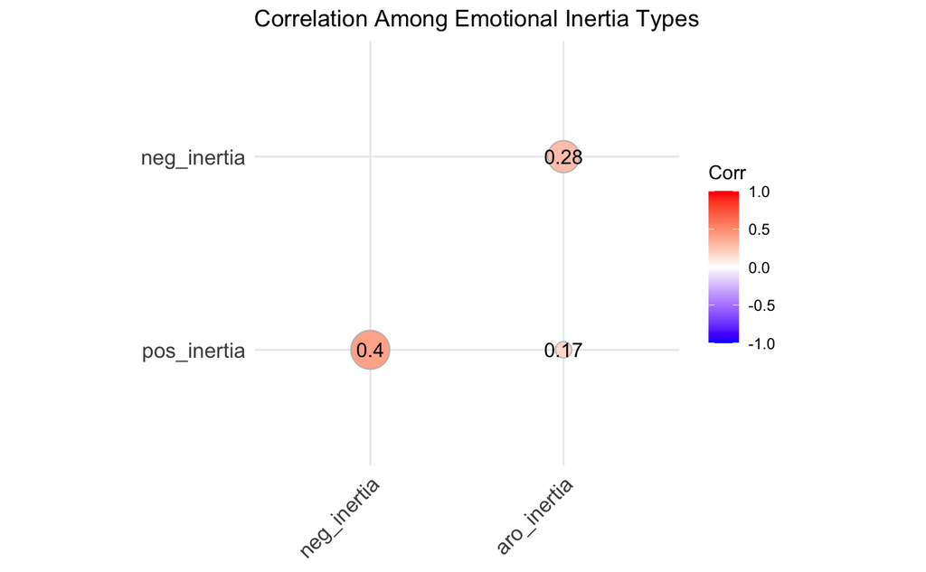

```r
library(ggcorrplot)

ggcorrplot(cor_matrix,
           method = "circle",
           type = "lower",
           lab = TRUE,
           title = "Correlation Among Emotional Inertia Types")
```

- `pos_inertia` and `neg_inertia` have moderate positive correlation (r = 0.401): people who tend to hold onto positive emotions also tend to hold onto negative emotions, suggesting emotional stickiness
- `aro_inertia` and `neg_inertia` have small-to-moderate positive correlation (r = 0.278): those who hold onto negative emotions also tend to stay aroused longer

## CLPM

### Cross-lag paths (how one emotion affect another at the next time point) & Inertia

```r
library(lavaan)
library(dplyr)

clpm_data <- dat %>%
  arrange(subj, trial.num) %>%
  group_by(subj) %>%
  mutate(
    Ipos_lag1 = lag(Ipos),
    Ineg_lag1 = lag(Ineg),
    Iaro_lag1 = lag(Iaro)
  ) %>%
  filter(!is.na(Ipos_lag1))

model_clpm <- '
  # Autoregressive (inertia) paths
  Ipos ~ a1 * Ipos_lag1
  Ineg ~ a2 * Ineg_lag1
  Iaro ~ a3 * Iaro_lag1

  # Cross-lagged paths
  Ipos ~ b1 * Ineg_lag1 + b2 * Iaro_lag1
  Ineg ~ c1 * Ipos_lag1 + c2 * Iaro_lag1
  Iaro ~ d1 * Ipos_lag1 + d2 * Ineg_lag1
'

fit_clpm <- sem(model_clpm, data = clpm_data)
summary(fit_clpm, standardized = TRUE, fit.measures = TRUE)
```

```
lavaan 0.6-19 ended normally after 30 iterations

  Estimator                                         ML
  Optimization method                           NLMINB
  Number of model parameters                        15

  Number of observations                         16224

Model Test User Model:

  Test statistic                                 0.000
  Degrees of freedom                                 0

Model Test Baseline Model:

  Test statistic                             17555.797
  Degrees of freedom                                12
  P-value                                        0.000

User Model versus Baseline Model:

  Comparative Fit Index (CFI)                    1.000
  Tucker-Lewis Index (TLI)                       1.000

Loglikelihood and Information Criteria:

  Loglikelihood user model (H0)            -102945.652
  Loglikelihood unrestricted model (H1)    -102945.652

  Akaike (AIC)                              205921.305
  Bayesian (BIC)                            206036.718
  Sample-size adjusted Bayesian (SABIC)     205989.049

Root Mean Square Error of Approximation:

  RMSEA                                          0.000
  90 Percent confidence interval - lower         0.000
  90 Percent confidence interval - upper         0.000
  P-value H_0: RMSEA <= 0.050                       NA
  P-value H_0: RMSEA >= 0.080                       NA
```

[output cut: 27 more lines]

```
    Ineg_lag1 (d2)   -0.063    0.008   -7.507    0.000   -0.063   -0.078

Covariances:
                   Estimate  Std.Err  z-value  P(>|z|)   Std.lv  Std.all
 .Ipos ~~
   .Ineg             -3.425    0.058  -59.271    0.000   -3.425   -0.526
   .Iaro              1.218    0.040   30.743    0.000    1.218    0.249
 .Ineg ~~
   .Iaro              1.886    0.041   45.562    0.000    1.886    0.383

Variances:
                   Estimate  Std.Err  z-value  P(>|z|)   Std.lv  Std.all
   .Ipos              6.482    0.072   90.067    0.000    6.482    0.974
   .Ineg              6.549    0.073   90.067    0.000    6.549    0.975
   .Iaro              3.700    0.041   90.067    0.000    3.700    0.860
```

- Positive inertia (0.137) and negative inertia (0.143) are about the same. Negative is slightly higher than positive.
- Arousal inertia (0.414) is much higher than the other two, meaning that arousal emotion is more likely to persist (slightly higher arousal inertia)
- All three types of emotional states (positive, negative, and arousal) exhibit significant inertia, with arousal showing the strongest carry-over effect from one trial to the next
- Ipos ~ Ineg_lag1 ($\beta$ = 0.166, p < .001): negative emotion predicts positive emotion in the next moment, which might reflect emotional rebound
- Ineg ~ Ipos_lag1 ($\beta$ = 0.172, p < .001): positive emotion enhances negative emotion in the next moment, which might reflect emotional mix or trial order effect
- Iaro ~ Ipos_lag1 ($\beta$ = -0.053, p < .001): positive emotion decreases arousal at the later stage
- Iaro ~ Ineg_lag1 ($\beta$ = -0.078, p < .001): negative emotion decreases arousal at the later stage
- Ipos ~ Iaro_lag1 and Ineg ~ Iaro_lag1 are not significant
- Conclusion:
  - **Both positive and negative emotions predict more of the opposite in the next moment**
  - **Arousal is reduced by both positive and negative emotions**
    - maybe a sign of emotional rebound or recovery
    - more likely to be a result of individual differences (some people are more responsive than others) under random trials within an experimental context, where individuals have “regression to the mean”. This might not be the case in real/natural context

#### Difference in paths by sex

```r
# Group by sex

fit_clpm_sex <- sem(model_clpm,
                    data = clpm_data,
                    group = "sex")
summary(fit_clpm_sex, standardized = TRUE, fit.measures = TRUE)
```

```
lavaan 0.6-19 ended normally after 161 iterations

  Estimator                                         ML
  Optimization method                           NLMINB
  Number of model parameters                        54
  Number of equality constraints                    18

  Number of observations per group:
    female                                        8632
    other                                          104
    male                                          7488

Model Test User Model:

  Test statistic                                70.669
  Degrees of freedom                                18
  P-value (Chi-square)                           0.000
  Test statistic for each group:
    female                                      19.632
    other                                       30.323
    male                                        20.714

Model Test Baseline Model:

  Test statistic                             17419.660
  Degrees of freedom                                36
  P-value                                        0.000

User Model versus Baseline Model:

  Comparative Fit Index (CFI)                    0.997
  Tucker-Lewis Index (TLI)                       0.994

Loglikelihood and Information Criteria:

  Loglikelihood user model (H0)            -102756.204
  Loglikelihood unrestricted model (H1)    -102720.870

  Akaike (AIC)                              205584.409
  Bayesian (BIC)                            205861.402
```

[output cut: 127 more lines]

```
   .Iaro              1.155    0.054   21.448    0.000    1.155    0.256
 .Ineg ~~
   .Iaro              1.651    0.056   29.644    0.000    1.651    0.365

Intercepts:
                   Estimate  Std.Err  z-value  P(>|z|)   Std.lv  Std.all
   .Ipos              2.062    0.053   39.082    0.000    2.062    0.844
   .Ineg              2.033    0.053   38.352    0.000    2.033    0.830
   .Iaro              2.178    0.040   54.163    0.000    2.178    1.083

Variances:
                   Estimate  Std.Err  z-value  P(>|z|)   Std.lv  Std.all
   .Ipos              5.821    0.095   61.188    0.000    5.821    0.975
   .Ineg              5.849    0.096   61.188    0.000    5.849    0.976
   .Iaro              3.504    0.057   61.188    0.000    3.504    0.867
```

```r
# Check for significant difference between men and women

model_clpm_free <- '
  # Inertia paths
  Ipos ~ c(a1f, a1m, a1o)*Ipos_lag1
  Ineg ~ c(a2f, a2m, a2o)*Ineg_lag1
  Iaro ~ c(a3f, a3m, a3o)*Iaro_lag1

  # Cross-lag
  Ipos ~ c(b1f, b1m, b1o)*Ineg_lag1 + c(b2f, b2m, b2o)*Iaro_lag1
  Ineg ~ c(c1f, c1m, c1o)*Ipos_lag1 + c(c2f, c2m, c2o)*Iaro_lag1
  Iaro ~ c(d1f, d1m, d1o)*Ipos_lag1 + c(d2f, d2m, d2o)*Ineg_lag1
'


fit_free <- sem(model_clpm_free, data = clpm_data, group = "sex")

# Whether there's significant difference between sex in at least one path
anova(fit_clpm_sex, fit_free)
```

```
Chi-Squared Difference Test

             Df    AIC    BIC  Chisq Chisq diff    RMSEA Df diff Pr(>Chisq)
fit_free      0 205550 205965  0.000
fit_clpm_sex 18 205584 205861 70.669     70.669 0.023261      18  3.482e-08 ***
---
Signif. codes:  0 ‘***’ 0.001 ‘**’ 0.01 ‘*’ 0.05 ‘.’ 0.1 ‘ ’ 1
```

- This shows that at least one or more paths (inertia or cross-lag) differ between males and females

```r
# Check which paths are significantly different

lavTestScore(fit_clpm_sex)
```

```
$test

total score test:
```

|  | test | X2 | df | p.value |
| --- | --- | --- | --- | --- |
| 1 | score | 68.394 | 18 | 0 |

```
$uni

univariate score tests:
```

|  | lhs | op | rhs | X2 | df | p.value |
| --- | --- | --- | --- | --- | --- | --- |
| 1 | .p1. | == | .p28. | 0.493 | 1 | 0.483 |
| 2 | .p1. | == | .p55. | 3.462 | 1 | 0.063 |
| 3 | .p2. | == | .p29. | 3.167 | 1 | 0.075 |
| 4 | .p2. | == | .p56. | 1.512 | 1 | 0.219 |
| 5 | .p3. | == | .p30. | 10.313 | 1 | 0.001 |
| 6 | .p3. | == | .p57. | 17.559 | 1 | 0.000 |
| 7 | .p4. | == | .p31. | 3.800 | 1 | 0.051 |
| 8 | .p4. | == | .p58. | 1.048 | 1 | 0.306 |
| 9 | .p5. | == | .p32. | 0.254 | 1 | 0.614 |
| 10 | .p5. | == | .p59. | 0.120 | 1 | 0.729 |

[output cut: 8 more lines]

```
NA
```

- .p3. vs. .p30. and .p3. vs. .p57. are significant (p < 0.05)

```r
# Understand which paths are them

pe <- parameterEstimates(fit_clpm_sex, standardized = TRUE)
pe[c(3, 30, 57), c("lhs", "op", "rhs", "group", "est", "std.all")]
```

|  | lhs | op | rhs | group | est | std.all |
| --- | --- | --- | --- | --- | --- | --- |
| 3 | Iaro | ~ | Iaro_lag1 | 1 | 0.408 | 0.413 |
| 30 | Iaro | ~ | Iaro_lag1 | 2 | 0.408 | 0.356 |
| 57 | Iaro | ~ | Iaro_lag1 | 3 | 0.408 | 0.402 |

- females (0.413) and males (0.402) are significantly different in arousal inertia (p < 0.001)
- females (0.413) and other (0.356) are also significantly different in arousal inertia (p = 0.001)

#### Difference in paths by ethnicity

```r
model_clpm_nolabel <- '
  Ipos ~ Ipos_lag1 + Ineg_lag1 + Iaro_lag1
  Ineg ~ Ineg_lag1 + Ipos_lag1 + Iaro_lag1
  Iaro ~ Iaro_lag1 + Ipos_lag1 + Ineg_lag1
'

fit_multigroup_free <- sem(model_clpm_nolabel, data = clpm_data, group = "ethn")
summary(fit_multigroup_free, standardized = TRUE)
```

[output not shown]

- Asian or Pacific Islander:
  - strong arousal inertia ($\beta$ = .43, p < .001).
  - Both prior positive ($\beta$ = –.05, p = .031) and negative emotion ($\beta$ = –.08, p < .001) significantly reduced subsequent arousal
- Black/African American:
  - Strongest Ipos inertia ($\beta$ = .187) among all groups (p < .001)
  - Arousal -> Positive emotion path is negative and significant ($\beta$=-.085, p = .012), suggesting arousal suppresses positivity here
- Latino/Hispanic:
  - Uniquely positive effect from prior arousal to later positive emotion ($\beta$ = .189, p < .001).
  - Had the strongest Iaro inertia ($\beta$ = .483, p < .001).
- White/Caucasian:
  - Negative cross-effects from both Ipos to Iaro ($\beta$ = -.104, p < .001) and Ineg to Iaro ($\beta$ = -.119, p < .001), showing a strong regulatory suppression of arousal by both emotion valences.
  - Effects tend to be more stable across emotional domains.
- American Indian/Native American or Alaskan Native:
  - The highest negative emotion inertia ($\beta$ = .21, p = .005)
  - The only group where prior negative emotion significantly increased arousal ($\beta$ = .16, p = .037)

#### Difference in paths by age

```r
library(dplyr)
library(broom)

# cross-lagged paths to analyze
paths <- list(
  Ipos_on_Ineg = c("Ipos", "Ineg_lag1"),
  Ipos_on_Aro = c("Ipos", "Iaro_lag1"),
  Ineg_on_Ipos = c("Ineg", "Ipos_lag1"),
  Ineg_on_Aro = c("Ineg", "Iaro_lag1"),
  Iaro_on_Ipos = c("Iaro", "Ipos_lag1"),
  Iaro_on_Ineg = c("Iaro", "Ineg_lag1")
)

results <- data.frame(path = character(), r = numeric(), p = numeric())

# run regression for each path + correlation with age
for (path_name in names(paths)) {
  lhs <- paths[[path_name]][1]
  rhs <- paths[[path_name]][2]

  # model each participant
  path_df <- clpm_data %>%
    group_by(subj) %>%
    filter(!is.na(.data[[lhs]]), !is.na(.data[[rhs]])) %>%
    do(tidy(lm(as.formula(paste(lhs, "~", rhs)), data = .))) %>%
    filter(term == rhs) %>%
    rename(estimate = estimate) %>%
    left_join(select(dat, subj, age), by = "subj")

  # find correlation with age
  cor_result <- cor.test(path_df$estimate, path_df$age)

  results <- rbind(results, data.frame(
    path = path_name,
    r = cor_result$estimate,
    p = cor_result$p.value
  ))
}

print(results)
```

[output not shown]

- Ipos_on_Ineg: As age increases, negative emotion exerts a stronger influence on subsequent positive emotion (r = 0.124, p < .001)
- Ipos_on_Aro: Higher arousal increasingly boosts next-step positive emotion with greater age (r = 0.202, p < .001)
- Ineg_on_Aro: Higher arousal is linked with lower next-step negative emotion, especially as age increases (r = -0.215, p < .001)
- Iaro_on_Ineg: With age, the influence of negative emotion on subsequent arousal slightly decreases (r = -0.038, p < .001)